# CustomerLens-Analytics: Preguntas Individuales

Andrés Martínez Reviriego

# Pregunta 1: ¿Son los descuentos rentables o provocan pérdidas?

## 1. Introducción

**¿Son los clientes que compran con descuentos realmente rentables a largo plazo, o estamos subvencionando a clientes de bajo valor?**

En muchos contextos de negocio, los descuentos se utilizan para estimular la compra a corto plazo. Sin embargo, una mayor intensidad promocional no siempre implica una mayor rentabilidad. Puede ocurrir que parte de los clientes que dependen de descuentos compren con frecuencia, pero generen menos valor económico neto que aquellos que compran sin promociones continuas.

Desde una perspectiva estratégica, esta pregunta es especialmente relevante porque condiciona la política comercial de la empresa: mantener promociones generalizadas, rediseñarlas para segmentos concretos o reducir su intensidad cuando no aportan valor sostenible.

En este análisis utilizamos como variable principal `Deals_Ratio` (proporción de compras con descuento sobre el total de compras) y la contrastamos frente a indicadores de valor del cliente. Dado que no disponemos de variables directas de margen o coste por cliente, trabajaremos con **proxies de rentabilidad** basadas en el gasto y en la intensidad de compra.

### 1.1. Objetivos

Este análisis trata los siguientes objetivos específicos:

- Describir cómo cambia el valor del cliente según su dependencia de descuentos.
- Comparar perfiles de clientes con uso bajo, medio y alto de promociones mediante métricas de gasto total, valor anualizado y ticket medio.
- Contrastar formalmente si las diferencias entre segmentos son estadísticamente significativas.
- Evaluar la asociación entre dependencia promocional y rentabilidad controlando variables demográficas y de comportamiento.
- Comprobar la robustez de los resultados y traducir la evidencia en una regla operativa de segmentación para negocio.

De este modo, el estudio no se limita a una comparación descriptiva, sino que prepara un marco analítico coherente para responder a la pregunta de negocio con evidencia cuantitativa.

## 2. Carga de datos y variables de trabajo

### 2.1. Carga de librerías y datos

En primer lugar cargamos las librerías necesarias para manipulación de datos (`dplyr`), lectura de ficheros (`readr`) y visualización (`ggplot2`). A continuación, importamos el dataset preprocesado generado en el notebook de limpieza, lo que garantiza consistencia metodológica con el resto del proyecto.

También definimos explícitamente las variables que vamos a utilizar en este análisis. Esta selección incluye:

- La variable clave de descuentos (`Deals_Ratio`).
- Variables de valor económico (`Total_Spending`, `Total_Purchases`, `Tenure_Days`).
- Variables de control relevantes para análisis posteriores (`Income`, `Recency`, `Age`, `Children_Home` y compras por canal).

Finalmente, inspeccionamos la estructura (`str`) para verificar tipos y detectar posibles inconsistencias antes de crear nuevas métricas.

```r
library(dplyr)
library(readr)
library(ggplot2)
library(tidyr)

data <- read_csv("./data/marketing_campaign_processed.csv", show_col_types = FALSE)

vars_objetivo <- c(
  "Deals_Ratio", "Total_Spending", "Total_Purchases", "Tenure_Days",
  "Income", "Recency", "Age", "Children_Home",
  "NumWebPurchases", "NumCatalogPurchases", "NumStorePurchases"
)

data %>% select(all_of(vars_objetivo)) %>% str()
```

```
## tibble [2,202 x 11] (S3: tbl_df/tbl/data.frame)
##  $ Deals_Ratio        : num [1:2202] 0.136 0.5 0.05 0.333 0.357 ...
##  $ Total_Spending     : num [1:2202] 1617 27 776 53 422 ...
##  $ Total_Purchases    : num [1:2202] 22 4 20 6 14 20 17 8 5 1 ...
##  $ Tenure_Days        : num [1:2202] 848 298 497 324 346 478 778 602 573 293 ...
##  $ Income             : num [1:2202] 58138 46344 71613 26646 58293 ...
##  $ Recency            : num [1:2202] 58 38 26 26 94 16 34 32 19 68 ...
##  $ Age                : num [1:2202] 57 60 49 30 33 47 43 29 40 64 ...
##  $ Children_Home      : num [1:2202] 0 2 0 1 1 1 1 1 1 2 ...
##  $ NumWebPurchases    : num [1:2202] 8 1 8 2 5 6 7 4 3 1 ...
##  $ NumCatalogPurchases: num [1:2202] 10 1 2 0 3 4 3 0 0 0 ...
##  $ NumStorePurchases  : num [1:2202] 4 2 10 4 6 10 7 4 2 0 ...
```

### 2.2. Checks rápidos de calidad

Antes de construir métricas, hacemos comprobaciones rápidas de calidad para asegurar que los cálculos de rentabilidad y segmentación no arrojen errores o sesgos por datos corruptos.

Comprobamos si falta información clave en las variables objetivo.

```r
data %>% summarise(across(all_of(vars_objetivo), ~ sum(is.na(.))))
```

```
## # A tibble: 1 x 11
##   Deals_Ratio Total_Spending Total_Purchases Tenure_Days Income Recency   Age Children_Home NumWebPurchases NumCatalogPurchases NumStorePurchases
##         <int>          <int>           <int>       <int>  <int>   <int> <int>         <int>           <int>               <int>             <int>
## 1           0              0               0           0      0       0     0             0               0                   0                 0
```

- **Resultado:** Todas las variables arrojan `0`. Esto confirma que la base de datos está completa.

Calculamos la proporción de clientes que *nunca* han comprado con descuento. Esto nos da la línea base de clientes 100% orgánicos.

```r
sum(data$Deals_Ratio == 0, na.rm = TRUE)
```

```
## [1] 40
```

```r
mean(data$Deals_Ratio == 0, na.rm = TRUE)
```

```
## [1] 0.0181653
```

Por último, verificamos si hay clientes sin vida útil registrada. Para calcular un “Valor Anualizado”, dividiremos el gasto total entre los años de vida del cliente. Si alguien lleva 0 días o tiene fecha negativa, rompería la matemática.

```r
sum(data$Tenure_Days <= 0, na.rm = TRUE)
```

```
## [1] 0
```

- **Resultado:** Encontramos `0` casos. Todos los clientes tienen al menos 1 día de antigüedad válida.

Por último, confirmamos que el dataset procesado que acabamos de cargar viene ya depurado del cliente anómalo (registros con `Deals_Ratio` fuera del rango válido de 0 a 1).

```r
# Verificamos la salud de la métrica clave
sum(data$Deals_Ratio > 1, na.rm = TRUE)
```

```
## [1] 0
```

- **Resultado:** Hemos verificado que no existen registros con `Deals_Ratio` imposible (> 1), tal y como se garantizó en el script de preprocesamiento. Esto asegura que todos los análisis posteriores de segmentación y regresión operen sobre proporciones matemáticas coherentes.

## 3. Definición operativa de rentabilidad (proxies)

Como el dataset no incluye beneficio real por cliente (margen neto, costes logísticos o coste promocional individual), definimos dos indicadores proxy que aproximan la rentabilidad desde distintas perspectivas:

- `Value_Annual`: gasto total anualizado según la antigüedad observada del cliente. Permite comparar clientes con diferente tiempo de relación con la empresa.
- `Spend_Per_Purchase`: gasto medio por compra (ticket medio), útil para identificar si la compra incentivada por descuento mantiene un valor unitario razonable.

Adicionalmente, se controla el riesgo de divisiones inválidas:

- Si `Tenure_Days <= 0`, se asigna `NA` en `Value_Annual`.
- Si `Total_Purchases == 0`, se asigna `0` en `Spend_Per_Purchase`.

Esta construcción mejora la interpretabilidad de los resultados y evita problemas técnicos en pasos posteriores.

```r
data <- data %>%
  mutate(
    Value_Annual = ifelse(Tenure_Days > 0, Total_Spending / (Tenure_Days / 365), NA_real_),
    Spend_Per_Purchase = ifelse(Total_Purchases > 0, Total_Spending / Total_Purchases, 0),
    Purchases_Annual = ifelse(Tenure_Days > 0, Total_Purchases / (Tenure_Days / 365), NA_real_)
  )
```

## 4. Segmentación por dependencia de descuento

Este enfoque permite responder con mayor claridad a preguntas del tipo:

- ¿Los clientes con uso alto de descuentos gastan más o menos que el resto?
- ¿Su valor anualizado es competitivo o inferior?
- ¿Su ticket medio sugiere dependencia promocional de bajo valor?

Finalmente, comprobamos el número de clientes por segmento para validar que la partición se ha realizado correctamente.

```r
q <- quantile(data$Deals_Ratio, probs = c(0, 1/3, 2/3, 1), na.rm = TRUE)

data <- data %>%
  mutate(
    Discount_Segment = cut(
      Deals_Ratio,
      breaks = q,
      include.lowest = TRUE,
      labels = c("Bajo", "Medio", "Alto")
    )
  )

data %>% count(Discount_Segment)
```

```
## # A tibble: 3 x 2
##   Discount_Segment     n
##   <fct>            <int>
## 1 Bajo               743
## 2 Medio              919
## 3 Alto               540
```

## 5. Análisis descriptivo inicial

Una vez definidos los segmentos, realizamos un resumen comparativo por grupo para obtener una primera evidencia empírica.

### 5.1. Tabla Resumen

Las métricas incluidas cumplen funciones complementarias:

- `n`: tamaño muestral de cada segmento.
- `mean_spending` y `median_spending`: nivel de gasto total (la mediana aporta robustez ante valores extremos).
- `mean_value_annual`: valor anualizado promedio, ajustado por antigüedad.
- `mean_spend_per_purchase`: ticket medio, indicador de calidad económica de cada compra.

Este bloque no establece causalidad, pero permite detectar patrones preliminares sobre si una mayor dependencia de descuentos se asocia con menor valor del cliente.

```r
data %>%
  group_by(Discount_Segment) %>%
  summarise(
    n = n(),
    mean_spending = mean(Total_Spending, na.rm = TRUE),
    median_spending = median(Total_Spending, na.rm = TRUE),
    iqr_spending = IQR(Total_Spending, na.rm = TRUE),
    p10_spending = quantile(Total_Spending, 0.10, na.rm = TRUE),
    p90_spending = quantile(Total_Spending, 0.90, na.rm = TRUE),
    mean_value_annual = mean(Value_Annual, na.rm = TRUE),
    median_value_annual = median(Value_Annual, na.rm = TRUE),
    p10_value_annual = quantile(Value_Annual, 0.10, na.rm = TRUE),
    p90_value_annual = quantile(Value_Annual, 0.90, na.rm = TRUE),
    mean_spend_per_purchase = mean(Spend_Per_Purchase, na.rm = TRUE)
  )
```

```
## # A tibble: 3 x 12
##   Discount_Segment     n mean_spending median_spending iqr_spending p10_spending p90_spending mean_value_annual median_value_annual p10_value_annual p90_value_annual mean_spend_per_purchase
##   <fct>            <int>         <dbl>           <dbl>        <dbl>        <dbl>        <dbl>             <dbl>               <dbl>            <dbl>            <dbl>                   <dbl>
## 1 Bajo               743         1187.            1159         739          495.        1901.              956.               824.             340.             1749.                    63.8
## 2 Medio              919          371.             137         548.          22         1036.              247.               121.              16.4             660.                    26.4
## 3 Alto               540          216.              89         217           38          501.              146.                74.1             27.5             355.                    20.0
```

Para complementar la tabla, visualizamos la distribución de las tres métricas clave por segmento. Este gráfico permite verificar si el patrón observado en medias se mantiene de forma consistente en toda la distribución y no solo en el promedio.

### 5.2. Visualización de Distribuciones

Para complementar la tabla, visualizamos la distribución de las tres métricas clave por segmento.

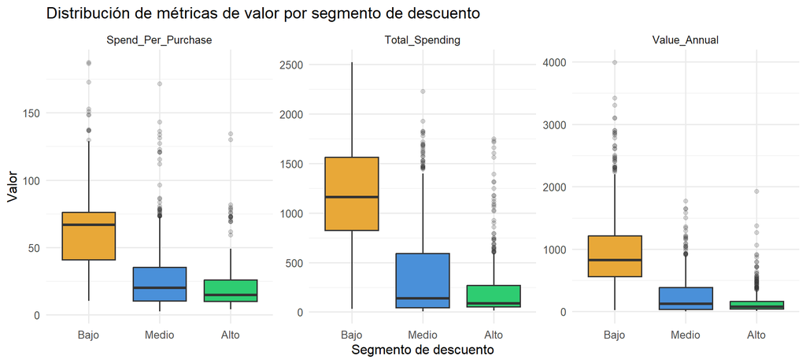

```r
plot_data <- data %>%
  select(Discount_Segment, Total_Spending, Value_Annual, Spend_Per_Purchase) %>%
  pivot_longer(
    cols = c(Total_Spending, Value_Annual, Spend_Per_Purchase),
    names_to = "Metrica",
    values_to = "Valor"
  )

ggplot(plot_data, aes(x = Discount_Segment, y = Valor, fill = Discount_Segment)) +
  geom_boxplot(outlier.alpha = 0.2) +
  facet_wrap(~Metrica, scales = "free_y") +
  scale_fill_manual(values = c("Bajo" = "#E8A838", "Medio" = "#4A90D9", "Alto" = "#2ECC71")) +
  labs(
    title = "Distribución de métricas de valor por segmento de descuento",
    x = "Segmento de descuento", y = "Valor"
  ) +
  theme_minimal(base_size = 12) +
  theme(legend.position = "none")
```

Los resultados descriptivos muestran un patrón consistente: a medida que aumenta la dependencia de descuentos (`Discount_Segment` de **Bajo** a **Alto**), disminuye de forma marcada el valor económico del cliente en todas las métricas analizadas. El grupo de uso bajo de descuentos concentra los mejores indicadores de gasto total, gasto anualizado y ticket medio, mientras que el grupo de uso alto presenta los niveles más reducidos.

Esta evidencia sugiere que los clientes más promodependientes no solo gastan menos en términos agregados, sino que además generan compras de menor valor unitario. Desde una perspectiva de negocio, el resultado preliminar apunta a un posible efecto de “subvención” de clientes de bajo valor cuando la estrategia comercial se apoya intensamente en promociones.

No obstante, al tratarse de un análisis descriptivo, estas conclusiones deben validarse en la siguiente fase mediante contrastes inferenciales y modelos con variables de control, con el fin de confirmar si la relación se mantiene tras ajustar por otros factores relevantes del comportamiento de compra.

## 6. Análisis inferencial

Hasta aquí hemos observado que los clientes con **bajo** uso de descuentos gastan más que los de **alto** uso. Pero esta es una muestra de ~2000 clientes. La pregunta ahora es: **¿si volviéramos a recoger datos de otros 2000 clientes, veríamos el mismo patrón, o fue casualidad?**

Para responder esto formalmente, empleamos un **contraste de hipótesis no paramétrico** (Kruskal-Wallis).

### 6.1. Kruskal-Wallis

```r
kw_vars <- c("Total_Spending", "Value_Annual", "Spend_Per_Purchase")
kw_results <- data.frame(
  Variable = kw_vars,
  H = NA_real_,
  p_value = NA_real_,
  Epsilon2 = NA_real_,
  stringsAsFactors = FALSE
)

for (i in seq_along(kw_vars)) {
  v <- kw_vars[i]
  tmp <- data %>% dplyr::select(Discount_Segment, all_of(v)) %>% na.omit()
  test <- kruskal.test(reformulate("Discount_Segment", response = v), data = tmp)
  H <- as.numeric(test$statistic)
  n <- nrow(tmp)
  k <- dplyr::n_distinct(tmp$Discount_Segment)
  eps2 <- (H - k + 1) / (n - k)

  kw_results$H[i] <- round(H, 3)
  kw_results$p_value[i] <- test$p.value
  kw_results$Epsilon2[i] <- round(eps2, 4)
}

knitr::kable(kw_results, digits = 4, caption = "Kruskal-Wallis y tamaño del efecto (epsilon²)")
```

Kruskal-Wallis y tamaño del efecto (epsilon²)

| Variable | H | p_value | Epsilon2 |
| --- | --- | --- | --- |
| Total_Spending | 1003.735 | 0 | 0.4555 |
| Value_Annual | 1073.656 | 0 | 0.4873 |
| Spend_Per_Purchase | 974.955 | 0 | 0.4425 |

### 6.2. Visualización: Distribución por Segmento

En lugar de tablas de p-values, mostramos directamente lo que el test confirma: los tres grupos están claramente separados.

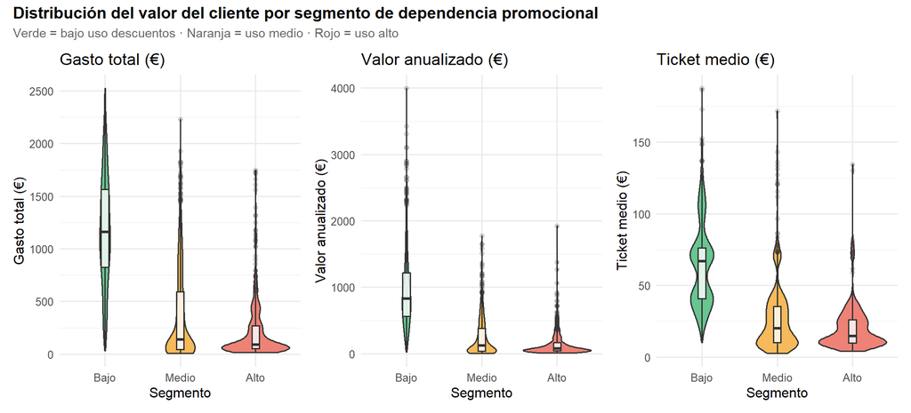

```r
library(patchwork)

make_violin <- function(df, var, label, color_low, color_mid, color_high) {
  ggplot(df %>% filter(!is.na(Discount_Segment)),
         aes(x = Discount_Segment, y = .data[[var]], fill = Discount_Segment)) +
    geom_violin(trim = TRUE, alpha = 0.7) +
    geom_boxplot(width = 0.1, fill = "white", alpha = 0.8, outlier.alpha = 0.2) +
    scale_fill_manual(values = c("Bajo" = color_low, "Medio" = color_mid, "Alto" = color_high)) +
    theme_minimal(base_size = 12) +
    theme(legend.position = "none") +
    labs(x = "Segmento", y = label, title = label)
}

v1 <- make_violin(data, "Total_Spending",    "Gasto total (€)",       "#27ae60", "#f39c12", "#e74c3c")
v2 <- make_violin(data, "Value_Annual",       "Valor anualizado (€)",  "#27ae60", "#f39c12", "#e74c3c")
v3 <- make_violin(data, "Spend_Per_Purchase", "Ticket medio (€)",      "#27ae60", "#f39c12", "#e74c3c")

v1 + v2 + v3 +
  plot_annotation(
    title = "Distribución del valor del cliente por segmento de dependencia promocional",
    subtitle = "Verde = bajo uso descuentos · Naranja = uso medio · Rojo = uso alto",
    theme = theme(plot.title = element_text(size = 14, face = "bold"),
                  plot.subtitle = element_text(size = 11, colour = "grey40"))
  )
```

Los tres gráficos confirman visualmente lo que el test Kruskal-Wallis detectó con p < 2.2e-16: los segmentos **bajo** (verde) están claramente elevados respecto al segmento **alto** (rojo) en las tres métricas: gasto total, valor anualizado y ticket medio.

## 7. Modelización multivariante: ¿La relación es real?

Estos gráficos son descriptivos, pero no demuestran por sí solos que sea **la dependencia de descuentos** la que causa el bajo valor. Podría ocurrir que los ingresos del cliente sean el factor real: los clientes de bajo ingreso usan más descuentos y gastan menos, creando una correlación aparente irreal.

Usamos regresión lineal para controlar este sesgo: manteniendo los valores de ingreso, edad, hijos y recency constantes, ¿sigue siendo `Deals_Ratio` un predictor negativo del valor?

### 7.1. Ajuste y resultado de los modelos

```r
modelo_annual <- lm(
  Value_Annual ~ Deals_Ratio + Income + Age + Children_Home + Recency + Tenure_Days,
  data = data
)

modelo_ticket <- lm(
  Spend_Per_Purchase ~ Deals_Ratio + Income + Age + Children_Home + Recency + Tenure_Days,
  data = data
)

resumen_modelos <- data.frame(
  Modelo         = c("Valor Anual (Value_Annual)", "Ticket Medio (Spend_Per_Purchase)"),
  Beta_Deals     = round(c(coef(modelo_annual)["Deals_Ratio"], coef(modelo_ticket)["Deals_Ratio"]), 2),
  p_value        = c(
    summary(modelo_annual)$coefficients["Deals_Ratio", "Pr(>|t|)"],
    summary(modelo_ticket)$coefficients["Deals_Ratio", "Pr(>|t|)"]
  ),
  R2    = round(c(summary(modelo_annual)$adj.r.squared, summary(modelo_ticket)$adj.r.squared), 3)
)

knitr::kable(resumen_modelos, digits = 4,
             caption = "Efecto de Deals_Ratio sobre el valor del cliente (controlando por ingreso, edad, hijos)",
             col.names = c("Var. Dependiente", "β (Deals_Ratio)", "p-value", "R²"))
```

Efecto de Deals_Ratio sobre el valor del cliente (controlando por ingreso, edad, hijos)

| Var. Dependiente | ß (Deals_Ratio) | p-value | R² |
| --- | --- | --- | --- |
| Valor Anual (Value_Annual) | -525.98 | 0 | 0.545 |
| Ticket Medio (Spend_Per_Purchase) | -30.77 | 0 | 0.524 |

### 7.2. Visualización de los efectos (gráficos de tendencia)

Para hacer estos hallazgos estadísticos mucho más intuitivos, visualicemos la relación empírica mediante gráficos de dispersión con líneas de tendencia. Así podemos ver “a simple vista” el efecto dual que tiene depender de los descuentos.

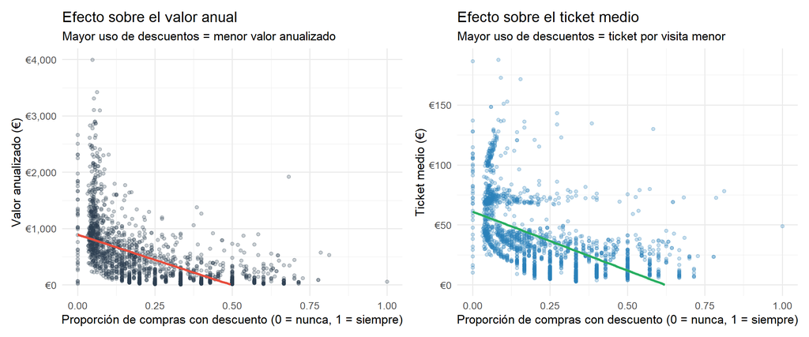

```r
library(patchwork)

p1 <- ggplot(data, aes(x = Deals_Ratio, y = Value_Annual)) +
  geom_point(alpha = 0.25, color = "#2c3e50", size = 1.5) +
  geom_smooth(method = "lm", color = "#e74c3c", fill = "#f1948a", alpha = 0.2) +
  theme_minimal(base_size = 13) +
  labs(
    title = "Efecto sobre el valor anual",
    subtitle = "Mayor uso de descuentos = menor valor anualizado",
    x = "Proporción de compras con descuento (0 = nunca, 1 = siempre)",
    y = "Valor anualizado (€)"
  ) +
  scale_y_continuous(labels = scales::dollar_format(prefix = "€"), limits = c(0, NA))

p2 <- ggplot(data, aes(x = Deals_Ratio, y = Spend_Per_Purchase)) +
  geom_point(alpha = 0.25, color = "#2980b9", size = 1.5) +
  geom_smooth(method = "lm", color = "#27ae60", fill = "#a9dfbf", alpha = 0.2) +
  theme_minimal(base_size = 13) +
  labs(
    title = "Efecto sobre el ticket medio",
    subtitle = "Mayor uso de descuentos = ticket por visita menor",
    x = "Proporción de compras con descuento (0 = nunca, 1 = siempre)",
    y = "Ticket medio (€)"
  ) +
  scale_y_continuous(labels = scales::dollar_format(prefix = "€"), limits = c(0, NA))

p1 + p2
```

Los gráficos resumen perfectamente el modelo lineal. A la izquierda (línea roja descendente), vemos cómo los clientes que abusan de los descuentos acaban dejando progresivamente menos dinero al año en la caja de la empresa. A la derecha (línea verde descendente), se demuestra que los clientes no compran más caro en cada visita aprovechando la oferta concreta, sino que el ticket medio se deprecia severamente. Sumando tickets más bajos y compras irregulares, el saldo total anual es profundamente perjudicial para el negocio.

## 8. Robustez: ¿Resisten nuestras conclusiones a valores extremos?

Hemos encontrado que descuentos ↔︎ bajo valor usando Kruskal-Wallis y regresión. Pero, ¿qué pasa si nuestra conclusión depende de 3 clientes con valores extremos que distorsionan todo?

### 8.1. Winsorización (p1-p99)

```r
winsor <- function(x, p = c(0.01, 0.99)) {
  q <- quantile(x, probs = p, na.rm = TRUE)
  pmin(pmax(x, q[1]), q[2])
}

data_rob <- data %>%
  mutate(
    Value_Annual_w = winsor(Value_Annual),
    Spend_Per_Purchase_w = winsor(Spend_Per_Purchase),
    Total_Spending_w = winsor(Total_Spending)
  )

kw_rob <- data.frame(
  Variable = c("Total_Spending_w", "Value_Annual_w", "Spend_Per_Purchase_w"),
  p_value = NA_real_,
  stringsAsFactors = FALSE
)

for (i in seq_len(nrow(kw_rob))) {
  v <- kw_rob$Variable[i]
  tmp <- data_rob %>% select(Discount_Segment, all_of(v)) %>% na.omit()
  kw_rob$p_value[i] <- kruskal.test(reformulate("Discount_Segment", response = v), data = tmp)$p.value
}

kw_rob$Variable <- c("Gasto_total_w", "Valor_anual_w", "Gasto_por_compra_w")

knitr::kable(kw_rob, digits = 4, caption = "Robustez: Kruskal-Wallis con variables winsorizadas")
```

Robustez: Kruskal-Wallis con variables winsorizadas

| Variable | p_value |
| --- | --- |
| Gasto_total_w | 0 |
| Valor_anual_w | 0 |
| Gasto_por_compra_w | 0 |

- **Todos los p-values = 0** (< 2.2e-16): Las diferencias entre segmentos persisten incluso después de recortar extremos (1% superior e inferior de cada variable).
- El hallazgo no depende de unos pocos clientes con valores extremos. La relación es estructural y sólida.

### 8.2. Recorte de muestra

```r
lim_inf <- quantile(data$Total_Spending, 0.01, na.rm = TRUE)
lim_sup <- quantile(data$Total_Spending, 0.99, na.rm = TRUE)

data_trim <- data %>%
  filter(Total_Spending >= lim_inf, Total_Spending <= lim_sup)

kw_trim <- kruskal.test(Total_Spending ~ Discount_Segment, data = data_trim)
kw_trim
```

```
##
##  Kruskal-Wallis rank sum test
##
## data:  Total_Spending by Discount_Segment
## Kruskal-Wallis chi-squared = 968.78, df = 2, p-value < 2.2e-16
```

Hemos pasado dos pruebas de robustez independientes. Podemos confirmar que nuestras conclusiones no son debido a outliers.

## 9. Traducción a negocio: detección de perfiles de riesgo promocional

Creamos una regla operativa para detectar clientes de “alto uso de descuento y bajo valor”.

```r
q_deals <- quantile(data$Deals_Ratio, 0.75, na.rm = TRUE)
q_value <- quantile(data$Value_Annual, 0.25, na.rm = TRUE)

perfil_riesgo <- data %>%
  mutate(
    Riesgo_Promo = ifelse(Deals_Ratio >= q_deals & Value_Annual <= q_value, 1, 0)
  ) %>%
  summarise(
    n_total = n(),
    n_riesgo = sum(Riesgo_Promo, na.rm = TRUE),
    pct_riesgo = round(mean(Riesgo_Promo, na.rm = TRUE) * 100, 2),
    gasto_medio_total = round(mean(Total_Spending, na.rm = TRUE), 2),
    gasto_medio_riesgo = round(mean(Total_Spending[Riesgo_Promo == 1], na.rm = TRUE), 2),
    gasto_medio_no_riesgo = round(mean(Total_Spending[Riesgo_Promo == 0], na.rm = TRUE), 2),
    mediana_gasto_riesgo = round(median(Total_Spending[Riesgo_Promo == 1], na.rm = TRUE), 2),
    mediana_gasto_no_riesgo = round(median(Total_Spending[Riesgo_Promo == 0], na.rm = TRUE), 2),
    sd_gasto_riesgo = round(sd(Total_Spending[Riesgo_Promo == 1], na.rm = TRUE), 2),
    sd_gasto_no_riesgo = round(sd(Total_Spending[Riesgo_Promo == 0], na.rm = TRUE), 2),
    revenue_riesgo = round(sum(Total_Spending[Riesgo_Promo == 1], na.rm = TRUE), 2),
    revenue_total = round(sum(Total_Spending, na.rm = TRUE), 2),
    pct_revenue_riesgo = round(revenue_riesgo / revenue_total * 100, 2),
    lift_riesgo = round(gasto_medio_riesgo / gasto_medio_total, 2)
  )

perfil_riesgo
```

```
## # A tibble: 1 x 14
##   n_total n_riesgo pct_riesgo gasto_medio_total gasto_medio_riesgo gasto_medio_no_riesgo mediana_gasto_riesgo mediana_gasto_no_riesgo sd_gasto_riesgo sd_gasto_no_riesgo revenue_riesgo
##     <int>    <dbl>      <dbl>             <dbl>              <dbl>                 <dbl>                <dbl>                   <dbl>           <dbl>              <dbl>          <dbl>
## 1    2202      362       16.4              608.               45.0                  719.                   38                     586            27.8               600.          16299
## # i 3 more variables: revenue_total <dbl>, pct_revenue_riesgo <dbl>, lift_riesgo <dbl>
```

Obtenemos un perfil de riesgo con las siguientes conclusiones clave:

- **~16% de clientes en riesgo**: Usando los criterios (Deals_Ratio ≥ p75 Y Value_Annual ≤ p25), aproximadamente 1 de cada 6 clientes combina alta dependencia de descuentos con bajo valor anualizado.
- **Diferencia de gasto extrema**: el gasto medio del grupo de riesgo es una mínima fracción del del resto, confirmando la divergencia de rentabilidad entre segmentos.
- **Contribución al revenue marginal**: el grupo de riesgo aporta un porcentaje mínimo del revenue total pese a ser ~16% de la cartera, lo que refuerza su baja rentabilidad.
- **Impacto económico**: Si la empresa dedica recursos promocionales a este grupo, está subvencionando clientes que generan valor marginal.

Para operativizar la regla, visualizamos la distribución del riesgo por segmento de descuento. El gráfico revela de inmediato dónde se concentra el problema:

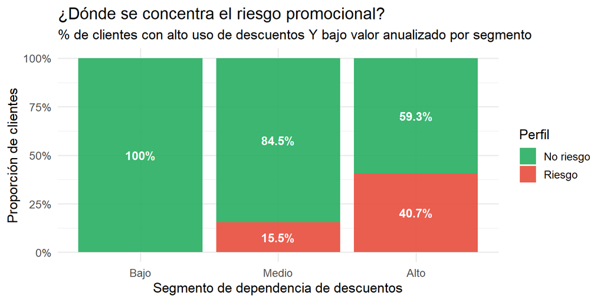

```r
perfil_segmento <- data %>%
  mutate(
    Riesgo_Promo = ifelse(Deals_Ratio >= q_deals & Value_Annual <= q_value, "Riesgo", "No riesgo")
  ) %>%
  count(Discount_Segment, Riesgo_Promo) %>%
  group_by(Discount_Segment) %>%
  mutate(Porcentaje = round(n / sum(n) * 100, 1)) %>%
  ungroup()

ggplot(perfil_segmento, aes(x = Discount_Segment, y = Porcentaje, fill = Riesgo_Promo)) +
  geom_bar(stat = "identity", position = "fill", alpha = 0.9) +
  geom_text(aes(label = paste0(Porcentaje, "%")),
            position = position_fill(vjust = 0.5),
            size = 4, fontface = "bold", color = "white") +
  scale_y_continuous(labels = scales::percent_format()) +
  scale_fill_manual(values = c("No riesgo" = "#27ae60", "Riesgo" = "#e74c3c")) +
  theme_minimal(base_size = 13) +
  labs(
    title = "¿Dónde se concentra el riesgo promocional?",
    subtitle = "% de clientes con alto uso de descuentos Y bajo valor anualizado por segmento",
    x = "Segmento de dependencia de descuentos",
    y = "Proporción de clientes",
    fill = "Perfil"
  )
```

La distribución de riesgo es fuertemente asimétrica:

- **Segmento bajo**: 0% en riesgo → Clientes de alto valor, sin necesidad de rediseñar sus incentivos.
- **Segmento medio**: ~15% en riesgo → Zona de alerta moderada, se debe monitorizar la evolución.
- **Segmento alto**: ~40% en riesgo → 4 de cada 10 clientes de este segmento tienen alto uso de descuentos y valor anualizado mínimo. Es el grupo prioritario para enfocar en la estrategia comercial.

## 10. Conclusiones

Obtenemos las siguientes conclusiones clave a partir del estudio:

1. **La dependencia al descuento perfila clientes de bajo valor relativo**: los tests no paramétricos confirman diferencias significativas. Los clientes que utilizan descuentos de manera agresiva aportan un valor anualizado comparativamente inferior.
2. **La relación es estructural y destruye margen**: al introducir modelos multivariantes, comprobamos que `Deals_Ratio` no solo mantiene una asociación negativa con el valor anual del cliente, sino que también deprime fuertemente el propio gasto medio en caja. Esta dualidad castiga al negocio, y se sostiene incluso controlando por el nivel de ingresos del usuario.
3. **Robustez confirmada**: las conclusiones se mantienen inalterables tras aplicar promedios winsorizados y recortes de muestra, lo que garantiza que los resultados no están impulsados por unos pocos valores extremos (outliers).
4. **Implicación principal de negocio (riesgo promocional)**: Hemos detectado que el riesgo de incentivar la no-rentabilidad se concentra de forma asimétrica; prácticamente 4 de cada 10 clientes altamente dependientes de los descuentos generan beneficios marginales para la empresa. Continuar destinando presupuesto promocional masivo o indiferenciado a este grupo supone una destrucción pura de rentabilidad y un elevado coste de oportunidad.

Con esta estudio, podemos concluir la necesidad crítica de analizar no solo los descuentos que se ofrecen, sino muy especialmente el tipo de cesta de productos que arman estos clientes, para entender por qué la promoción no logra rentabilizarlos. Esto abre la puerta directamente a nuestra segunda pregunta de investigación.

# Pregunta 2: ¿Existen patrones ocultos en el “mix de productos” que compran los clientes según su dependencia de descuentos?

## 11. Introducción

En la primera parte del análisis comprobamos que los clientes con alta dependencia de promociones (`Discount_Segment = Alto`) son menos rentables. Sin embargo, surge una pregunta derivada: **¿En qué difieren exactamente sus compras?**

### 11.1 Objetivos

- Explorar visualmente cómo cambia la composición relativa de la cesta y el **volumen de gasto absoluto** en cada categoría según el segmento de descuento.
- Transformar y discretizar las variables de productos numéricas en categorías interpretables.
- Aplicar minería de datos (algoritmo **Apriori**) y visualización comparada para descubrir patrones de consumo de alto y bajo valor específicos de cada segmento.

## 12. Preparación de datos y discretización

Para usar reglas de asociación, necesitamos variables categóricas o factores (ítems). Convertiremos el gasto en cada categoría (Vinos, Carnes, Frutas, Pescado, Dulces, Oro) en dos niveles: `High` (por encima de la mediana) y `Low` (por debajo o igual a la mediana).

```r
if(!requireNamespace("arules", quietly = TRUE)) install.packages("arules", repos = "http://cran.us.r-project.org")
library(arules)
if(!requireNamespace("arulesViz", quietly = TRUE)) install.packages("arulesViz", repos = "http://cran.us.r-project.org")
library(arulesViz)

product_vars <- c("MntWines", "MntFruits", "MntMeatProducts",
                  "MntFishProducts", "MntSweetProducts", "MntGoldProds")

discretize_product <- function(x, name) {
  med <- median(x, na.rm = TRUE)
  factor(ifelse(x > med, paste0("High_", name), paste0("Low_", name)))
}

data_basket <- data %>%
  filter(!is.na(Discount_Segment)) %>%
  mutate(
    Wines = discretize_product(MntWines, "Wines"),
    Fruits = discretize_product(MntFruits, "Fruits"),
    Meat = discretize_product(MntMeatProducts, "Meat"),
    Fish = discretize_product(MntFishProducts, "Fish"),
    Sweets = discretize_product(MntSweetProducts, "Sweets"),
    Gold = discretize_product(MntGoldProds, "Gold")
  ) %>%
  select(Discount_Segment, Wines, Fruits, Meat, Fish, Sweets, Gold)
```

## 13. Análisis Exploratorio de Datos (EDA) del mix de productos

Antes de lanzar el algoritmo de Machine Learning, hagamos un análisis visual. ¿Cómo se distribuye el gasto total promedio en cada producto según el segmento de descuentos?

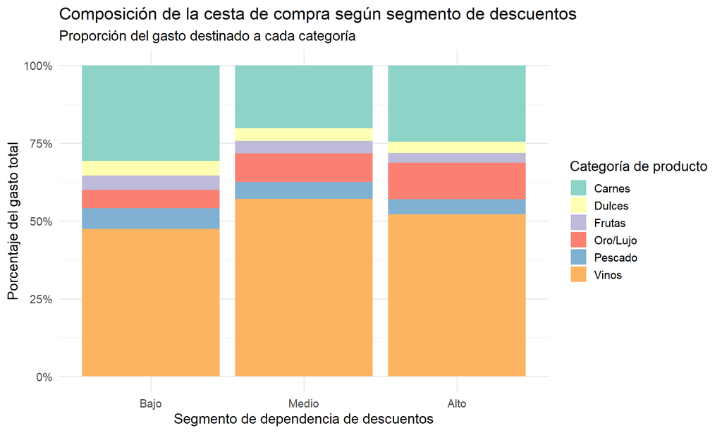

```r
# Etiquetas más legibles para los productos
product_labels <- c(
  MntWines = "Vinos", MntFruits = "Frutas",
  MntMeatProducts = "Carnes", MntFishProducts = "Pescado",
  MntSweetProducts = "Dulces", MntGoldProds = "Oro/Lujo"
)

data_long <- data %>%
  filter(!is.na(Discount_Segment)) %>%
  select(Discount_Segment, all_of(product_vars)) %>%
  group_by(Discount_Segment) %>%
  summarise(across(everything(), mean, na.rm = TRUE)) %>%
  pivot_longer(cols = -Discount_Segment, names_to = "Producto", values_to = "Gasto_Medio") %>%
  mutate(Producto = product_labels[Producto])

ggplot(data_long, aes(x = Discount_Segment, y = Gasto_Medio, fill = Producto)) +
  geom_bar(stat = "identity", position = "fill") +
  scale_y_continuous(labels = scales::percent_format()) +
  scale_fill_brewer(palette = "Set3") +
  theme_minimal(base_size = 14) +
  labs(
    title = "Composición de la cesta de compra según segmento de descuentos",
    subtitle = "Proporción del gasto destinado a cada categoría",
    x = "Segmento de dependencia de descuentos",
    y = "Porcentaje del gasto total",
    fill = "Categoría de producto"
  )
```

El gráfico muestra cómo evoluciona las cantidades de las distintas categorías de cada producto. Se observa visualmente que la *composición* de su cesta varía en función de la dependencia en los descuentos.

Para complementar, podemos ver el gasto medio en **euros absolutos** por categoría y segmento, lo que permite entender no solo la composición sino también el volumen real de cada grupo:

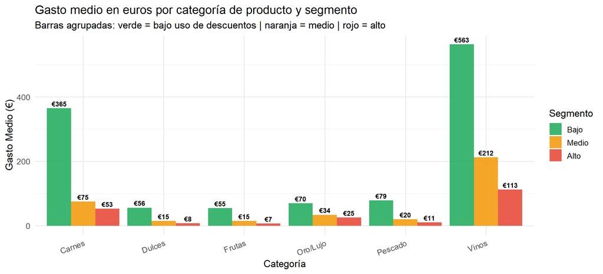

```r
data_abs <- data %>%
  filter(!is.na(Discount_Segment)) %>%
  select(Discount_Segment, all_of(product_vars)) %>%
  group_by(Discount_Segment) %>%
  summarise(across(everything(), mean, na.rm = TRUE)) %>%
  pivot_longer(cols = -Discount_Segment, names_to = "Producto", values_to = "Gasto_Medio") %>%
  mutate(Producto = product_labels[Producto])  # lookup por nombre, sin conflicto con arules

ggplot(data_abs, aes(x = Producto, y = Gasto_Medio, fill = Discount_Segment)) +
  geom_bar(stat = "identity", position = "dodge", alpha = 0.9) +
  geom_text(aes(label = paste0("€", round(Gasto_Medio))),
            position = position_dodge(width = 0.9),
            vjust = -0.4, size = 3.2, fontface = "bold") +
  scale_fill_manual(values = c("Bajo" = "#27ae60", "Medio" = "#f39c12", "Alto" = "#e74c3c")) +
  theme_minimal(base_size = 13) +
  labs(
    title = "Gasto medio en euros por categoría de producto y segmento",
    subtitle = "Barras agrupadas: verde = bajo uso de descuentos | naranja = medio | rojo = alto",
    x = "Categoría", y = "Gasto Medio (€)",
    fill = "Segmento"
  ) +
  theme(axis.text.x = element_text(angle = 20, hjust = 1))
```

## 14. Minería de reglas de asociación (Apriori)

Buscamos combinaciones concretas de comportamiento. Queremos reglas que tengan en su antecedente (LHS) un tipo de segmento de descuento, para ver qué productos tienden a comprar (RHS).

### 14.1. Transacciones y generación

Buscamos patrones frecuentes. Ajustamos un soporte mínimo del 10% y una confianza del 60% para obtener reglas robustas.

```r
transacciones <- as(data_basket, "transactions")

# Apriori
reglas <- apriori(transacciones,
                  parameter = list(supp = 0.1, conf = 0.6, target = "rules", minlen = 2))
```

```
## Apriori
##
## Parameter specification:
##  confidence minval smax arem  aval originalSupport maxtime support minlen maxlen target  ext
##         0.6    0.1    1 none FALSE            TRUE       5     0.1      2     10  rules TRUE
##
## Algorithmic control:
##  filter tree heap memopt load sort verbose
##     0.1 TRUE TRUE  FALSE TRUE    2    TRUE
##
## Absolute minimum support count: 220
##
## set item appearances ...[0 item(s)] done [0.00s].
## set transactions ...[15 item(s), 2202 transaction(s)] done [0.00s].
## sorting and recoding items ... [15 item(s)] done [0.00s].
## creating transaction tree ... done [0.00s].
## checking subsets of size 1 2 3 4 5 6 7 done [0.01s].
## writing ... [1024 rule(s)] done [0.00s].
## creating S4 object  ... done [0.00s].
```

```r
print(paste("Se han encontrado", length(reglas), "reglas en total."))
```

```
## [1] "Se han encontrado 1024 reglas en total."
```

### 14.2. Patrones de consumo por segmento (visualización directa)

En lugar de mostrar reglas individuales (que pueden repetir el mismo consecuente), visualizamos directamente el **porcentaje de clientes con consumo alto** en cada categoría de producto, por segmento. Esto resume en un solo gráfico el mensaje principal de las reglas Apriori.

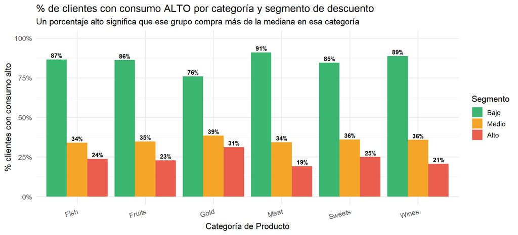

```r
# Calculamos % de clientes con nivel "High" por producto y segmento
pct_high <- data_basket %>%
  pivot_longer(cols = c(Wines, Fruits, Meat, Fish, Sweets, Gold),
               names_to = "Producto", values_to = "Nivel") %>%
  group_by(Discount_Segment, Producto) %>%
  summarise(
    pct_high = mean(grepl("^High", as.character(Nivel)), na.rm = TRUE) * 100,
    .groups = "drop"
  )

ggplot(pct_high, aes(x = Producto, y = pct_high, fill = Discount_Segment)) +
  geom_bar(stat = "identity", position = "dodge", alpha = 0.9) +
  geom_text(aes(label = paste0(round(pct_high), "%")),
            position = position_dodge(width = 0.9),
            vjust = -0.4, size = 3.3, fontface = "bold") +
  scale_fill_manual(values = c("Bajo" = "#27ae60", "Medio" = "#f39c12", "Alto" = "#e74c3c")) +
  scale_y_continuous(limits = c(0, 100), labels = scales::percent_format(scale = 1)) +
  theme_minimal(base_size = 13) +
  labs(
    title = "% de clientes con consumo ALTO por categoría y segmento de descuento",
    subtitle = "Un porcentaje alto significa que ese grupo compra más de la mediana en esa categoría",
    x = "Categoría de Producto", y = "% clientes con consumo alto",
    fill = "Segmento"
  ) +
  theme(axis.text.x = element_text(angle = 15, hjust = 1))
```

### 14.3. Reglas más sólidas por segmento

Presentamos las reglas específicas de mayor confianza generadas por Apriori para cada segmento:

```r
reglas_alto <- subset(reglas, subset = lhs %in% "Discount_Segment=Alto")
reglas_medio <- subset(reglas, subset = lhs %in% "Discount_Segment=Medio")
reglas_bajo <- subset(reglas, subset = lhs %in% "Discount_Segment=Bajo")

cat("=== TOP 5 reglas para segmento ALTO (por confianza) ===\n")
```

```
## === TOP 5 reglas para segmento ALTO (por confianza) ===
```

```r
inspect(head(sort(reglas_alto, by = "confidence", decreasing = TRUE), 5))
```

```
##     lhs                                                                                                             rhs             support   confidence coverage  lift     count
## [1] {Discount_Segment=Alto, Wines=Low_Wines, Fish=Low_Fish, Gold=Low_Gold}                                       => {Meat=Low_Meat} 0.1262489 0.9893238  0.1276113 1.969703 278
## [2] {Discount_Segment=Alto, Wines=Low_Wines, Fruits=Low_Fruits, Fish=Low_Fish, Gold=Low_Gold}                    => {Meat=Low_Meat} 0.1158038 0.9883721  0.1171662 1.967808 255
## [3] {Discount_Segment=Alto, Wines=Low_Wines, Fish=Low_Fish, Sweets=Low_Sweets, Gold=Low_Gold}                    => {Meat=Low_Meat} 0.1139873 0.9881890  0.1153497 1.967443 251
## [4] {Discount_Segment=Alto, Wines=Low_Wines, Fruits=Low_Fruits, Fish=Low_Fish, Sweets=Low_Sweets, Gold=Low_Gold} => {Meat=Low_Meat} 0.1085377 0.9876033  0.1099001 1.966277 239
## [5] {Discount_Segment=Alto, Wines=Low_Wines, Fruits=Low_Fruits, Gold=Low_Gold}                                   => {Meat=Low_Meat} 0.1276113 0.9790941  0.1303361 1.949336 281
```

```r
cat("\n=== TOP 5 reglas para segmento MEDIO (por confianza) ===\n")
```

```
##
## === TOP 5 reglas para segmento MEDIO (por confianza) ===
```

```r
inspect(head(sort(reglas_medio, by = "confidence", decreasing = TRUE), 5))
```

```
##     lhs                                                                                                              rhs             support   confidence coverage  lift     count
## [1] {Discount_Segment=Medio, Wines=Low_Wines, Fruits=Low_Fruits, Fish=Low_Fish, Gold=Low_Gold}                    => {Meat=Low_Meat} 0.1734787 0.9973890  0.1739328 1.985760 382
## [2] {Discount_Segment=Medio, Wines=Low_Wines, Fruits=Low_Fruits, Fish=Low_Fish, Sweets=Low_Sweets, Gold=Low_Gold} => {Meat=Low_Meat} 0.1671208 0.9972900  0.1675749 1.985563 368
## [3] {Discount_Segment=Medio, Wines=Low_Wines, Fruits=Low_Fruits, Gold=Low_Gold}                                   => {Meat=Low_Meat} 0.1871026 0.9951691  0.1880109 1.981340 412
## [4] {Discount_Segment=Medio, Wines=Low_Wines, Fruits=Low_Fruits, Sweets=Low_Sweets, Gold=Low_Gold}                => {Meat=Low_Meat} 0.1757493 0.9948586  0.1766576 1.980722 387
## [5] {Discount_Segment=Medio, Wines=Low_Wines, Fish=Low_Fish, Sweets=Low_Sweets, Gold=Low_Gold}                    => {Meat=Low_Meat} 0.1730245 0.9921875  0.1743869 1.975404 381
```

```r
cat("\n=== TOP 5 reglas para segmento BAJO (por lift) ===\n")
```

```
##
## === TOP 5 reglas para segmento BAJO (por lift) ===
```

```r
inspect(head(sort(reglas_bajo, by = "lift", decreasing = TRUE), 5))
```

```
##     lhs                         rhs                support confidence  coverage     lift count
## [1] {Discount_Segment=Bajo,
##      Wines=High_Wines,
##      Fruits=High_Fruits,
##      Fish=High_Fish,
##      Sweets=High_Sweets,
##      Gold=High_Gold}         => {Meat=High_Meat} 0.1857402  1.0000000 0.1857402 2.009124   409
## [2] {Discount_Segment=Bajo,
##      Wines=High_Wines,
##      Fruits=High_Fruits,
##      Fish=High_Fish,
##      Gold=High_Gold}         => {Meat=High_Meat} 0.2007266  0.9977427 0.2011807 2.004589   442
## [3] {Discount_Segment=Bajo,
##      Wines=High_Wines,
##      Fish=High_Fish,
##      Sweets=High_Sweets,
##      Gold=High_Gold}         => {Meat=High_Meat} 0.1975477  0.9977064 0.1980018 2.004516   435
## [4] {Discount_Segment=Bajo,
##      Wines=High_Wines,
##      Fruits=High_Fruits,
##      Fish=High_Fish,
##      Sweets=High_Sweets}     => {Meat=High_Meat} 0.2234332  0.9959514 0.2243415 2.000990   492
## [5] {Discount_Segment=Bajo,
##      Wines=High_Wines,
##      Fruits=High_Fruits,
##      Sweets=High_Sweets,
##      Gold=High_Gold}         => {Meat=High_Meat} 0.1939146  0.9953380 0.1948229 1.999758   427
```

## 15. Visualización del grafo de asociaciones

Para sintetizar las reglas, dibujamos un grafo de las métricas obtenidas.

```r
# Para que el grafo muestre la realidad completa, combinamos el Top 5 de cada segmento
# (Si cogemos el top global, el segmento 'Bajo' acapara todo el ranking por su alto lift)
top_reglas_mixtas <- c(
  head(sort(reglas_alto, by = "confidence", decreasing = TRUE), 5),
  head(sort(reglas_medio, by = "confidence", decreasing = TRUE), 5),
  head(sort(reglas_bajo, by = "lift", decreasing = TRUE), 5)
)

plot(top_reglas_mixtas, method = "graph", engine = "htmlwidget", main = "Top 15 Reglas: Contraste entre Segmentos")
```

[output not shown]

[interactive chart not shown]

## 16. Conclusiones

Con esta aproximación visual, obtenemos una radiografía de consumo que complementa perfectamente la regresión de la Pregunta 1. La conclusión final que extraemos de ambas preguntas es la necesidad crítica de analizar no solo los descuentos que se ofrecen, sino muy especialmente el perfil y comportamiento de los clientes que los utilizan para poder ajustar los descuentos de manera más eficiente.